# Midterm

Laura Jacobson

2/13/2022

Loading packages

# Midterm (Due Sunday 2/13/2022 at 11:55 pm)

Please submit your `.Rmd` and `.html` files in Sakai. If you are working together, both people should submit the files.

## 60 / 60 points total

You must use each of the following functions at least once:

- `mutate()`
- `group_by()`
- `summarize()`
- `ggplot()`

and *at least one* of the following:

- `case_when()`
- `across()`
- `*_join()` (i.e. `left_join()`)
- `pivot_*()` (i.e. `pivot_longer()`)

## Define Your Research Question (10 points)

## Data Source

I selected the Premise Women’s Health COVID-19 Health Services Disruption Survey 2021. This survey is from Institute for Health Metrics and Evaluation (IHME) and it was developed to assess the level of disruption to a range of health services resulting from the COVID-19 pandemic. I selected the women’s health specific survey as I am interested in sexual and reproductive health matters.

This survey was conducted in 51 countries using the smartphone-based platform. There were 4,319 respondents from the general population, aged 16-49 years, who identified as women. The survey focused on the level of disruption to family planning and reproductive health services and changes in risk of gender-based violence. Data are available here: http://ghdx.healthdata.org/record/ihme-data/premise-womens-health-covid-19-health-services-disruption-survey-2021

> *Define your research question below. What about the data interests you? What is a specific question you want to find out about the data?*

I am interested in this data set for several reasons. My dissertation research focuses on self-managed abortion in a global context and so I have a lot of knowledge of the sexual and reproductive health literature, this specific data set and research question is related but new to me. I am interested in the complex intersection of contraceptive use, fertility, safety, and alcohol use of partners. Additionally, it has a wide geographic spread and may be interesting to look at differences by country-level income.

My research question is: **How has the COVID-19 pandemic altered pregnancy desires and contraceptive use among women and are there differences by country-level income?**

I will also look at if there are perceived domestic safety changes including a perceived change in partners alcohol use.

> *Given your question, what is your expectation about the data?*

My expectation is that the Covid-19 pandemic has altered pregnancy desires. The pandemic has been a multi year major disruption to the lives of many. Pregnancy desires have a lot of contributing factors and therefore, I suspect that because many life patterns have been disrupted, they may accumulate to impact pregnancy desire. I also expect to see some disruption or changes in contraceptive use. I may8 disruption to clinic-based access to be more pronounced in lower income countries. In wealthier nations such as the US, in person visits and telehealth services allow for access to contraceptives at near same efficiency as before the pandemic. In lower income nations, contraceptive access was a challenge before the pandemic. With regards to perceived domestic safety, I do not have a hypothesis, this portion of the question will be exploratory.

## Loading the Data (10 points)

> *Load the data below and use `dplyr::glimpse()` or `skimr::skim()` on the data. You should upload the data file into the `data` directory.*

```r
#Loading the data
IHME_data <- read.csv("data/IHME_PREM_WMN_HEALTH_2021_Y2021M09D14.CSV")

#checking out the data
glimpse(IHME_data)
```

```
## Rows: 4,319
## Columns: 103
## $ country                           <chr> "Afghanistan", "Afghanistan", "Afgha…
## $ location_id                       <int> 160, 160, 160, 160, 160, 160, 160, 1…
## $ observation_id                    <chr> "wmn_4944344565153792", "wmn_5848008…
## $ user_id                           <chr> "wmn_5978217477570560", "wmn_5912238…
## $ submission_time                   <chr> "2021-05-28 22:51:28.502 UTC", "2021…
## $ age                               <int> 2, 3, 2, 2, 2, 2, 3, 3, 2, 3, 3, 2, …
## $ gender                            <int> 2, 2, 2, 2, 2, 2, 99, 2, 2, 2, 99, 9…
## $ geography                         <int> 1, 2, 1, 2, 3, 2, 2, 2, 2, 1, 2, 2, …
## $ financial_situation               <int> 7, 5, 2, 6, 2, 99, 2, 5, 99, 2, 99, …
## $ education                         <int> 10, 13, 10, 13, 9, 10, 11, 8, 10, 14…
## $ employment_status                 <int> 14, 11, 15, 15, 17, 15, 15, 21, 15, …
## $ ethnicity                         <chr> "Prefer not to answer", "Pashtun", "…
## $ religion                          <chr> "Sunni (Muslim)", "Sunni (Muslim)", …
```

[output cut: 90 more lines]

```r
#Selecting columns I'm interested in to reduce the size of the data and creating a new data set to clean
IHME_data_clean <- IHME_data %>% select(country, age, gender, geography, financial_situation, education, employment_status, religion, wmn_con_access_difficulty, wmn_partner_alcohol_change, wmn_con_use_change, wmn_how_safe_change, wmn_partner_violence, wmn_pregnancy_desire, wmn_pregnancy_change_how)
```

> *If there are any quirks that you have to deal with `NA` coded as something else, or it is multiple tables, please make some notes here about what you need to do before you start transforming the data in the next section.*

I can see from glimpse that there is a lot of missing data which may impact my analyses, but it is displayed as NA. Some of the NA values are entered into the survey responses as 99. These will be recoded in the data transformation section below.

**Make sure your data types are correct!** I want to convert the country variable from a character to a factor and then collapse into 3 groups low, middle, and high income countries based on the World Bank classifications. This will make countries comparisons easier and possible by income of nation. Note that “low-income” contains both low and lower middle income countries. Source:https://blogs.worldbank.org/opendata/new-world-bank-country-classifications-income-level-2021-2022

```r
#converting the country variable into a factor
IHME_data_clean <- IHME_data_clean %>%  mutate(country = factor(country))

#collapsing country variable into 3 groups by income
IHME_data_clean <- IHME_data_clean %>%
  mutate(country_income = fct_collapse(country,
       low_income = c("Afghanistan", "Algeria","Bangladesh","Benin", "Burkina Faso", "Cambodia", "Colombia", "Democratic Republic of the Congo", "Egypt", "El Salvador", "Ethiopia","Ghana", "Guatemala", "Honduras", "Indonesia", "Kenya", "Liberia", "Mali", "Mozambique", "Nicaragua", "Nigeria", "Philippines", "Rwanda", "Senegal", "Sierra Leone", "Somalia", "Tunisia", "Uganda", "Ukraine", "United Republic of Tanzania", "Viet Nam", "Yemen", "Zambia", "Zimbabwe"),
       middle_income = c("Albania", "Argentina","Bosnia and Herzegovina", "Brazil", "Costa Rica", "Dominican Republic", "Ecuador", "India", "Iraq", "Jamaica", "Jordan", "Kazakhstan", "Lebanon", "Malaysia", "Mexico", "Panama", "Peru", "Serbia", "South Africa", "Thailand", "Turkey"  ),
       high_income = c("Bahrain", "Chile", "France", "Hong Kong", "Italy", "Ivory Coast", "United States","Lithuania", "Morocco", "Oman", "Poland", "Republic of Korea", "Saudi Arabia", "Spain", "Taiwan (Province of China)", "Trinidad and Tobago", "United Arab Emirates", "United Kingdom", "Uruguay", "Venezuela (Bolivarian Republic of)")
       ))
#viewing in a table to check this worked
IHME_data_clean %>% tabyl(country_income) %>% adorn_totals() %>% adorn_pct_formatting()
```

```
##  country_income    n percent
##      low_income 2150   49.8%
##   middle_income 1044   24.2%
##     high_income 1125   26.0%
##           Total 4319  100.0%
```

## Transforming the data (15 points)

> *If the data needs to be transformed in any way (values recoded, pivoted, etc), do it here. Examples include transforming a continuous variable into a categorical using `case_when()`, etc.*

I am making several data transformations to recode the integer variables into characters so that they are interpretable. For example, presently gender = 1, this will be recoded to a new variable gender_name = woman vs man. Note that all participants in this specific survey identified as women. All information is available in the IHME code book.

```r
#recoding gender variable
IHME_data_clean <- IHME_data_clean %>% mutate(
  gender_name = case_when(gender == 2 ~ "woman",
                  gender ==1 ~ "man",
                  gender == 99 ~ "NA"))

#Change the NAs so R codes them as missing
IHME_data_clean <- IHME_data_clean  %>%  mutate(
  gender_name = na_if(gender_name, "NA"))

#making a tabyl to check that it worked, as expected all participants are women (3.6% missing)
IHME_data_clean %>% tabyl(gender_name)
```

```
##  gender_name    n    percent valid_percent
##        woman 4161 0.96341746             1
##         <NA>  158 0.03658254            NA
```

```r
#making age categories out of the survey responses
IHME_data_clean <- IHME_data_clean %>% mutate(
  age_category = case_when(age == 1 ~ "<16",
                           age == 2 ~ "16-25",
                           age == 3 ~ "26-35",
                           age == 4 ~ "36-45",
                           age == 5 ~ "46+",
                           age == 99 ~ "NA"
                          ))
#Change the NAs so R codes them as missing
IHME_data_clean <- IHME_data_clean  %>%  mutate(
  age_category = na_if(age_category, "NA"))

#making a tabyl to check that it worked
IHME_data_clean %>% tabyl(age_category)
```

```
##  age_category    n    percent
##         16-25 1446 0.33479972
##         26-35 1755 0.40634406
##         36-45  920 0.21301227
##           46+  198 0.04584395
```

```r
#defining the geography
IHME_data_clean <- IHME_data_clean %>% mutate(
  geography_name = case_when(geography == 1 ~ "urban",
                        geography == 2 ~ "peri-urban",
                        geography == 3 ~ "rural",
                        geography == 99 ~ "NA"
                        ))
#Change the NAs so R codes them as missing
IHME_data_clean <- IHME_data_clean  %>%  mutate(
  geography_name = na_if(geography_name, "NA"))

#making a tabyl to check that it worked
IHME_data_clean %>% tabyl(geography_name)
```

```
##  geography_name    n      percent valid_percent
##      peri-urban 1286 0.2977541097     0.2978231
##           rural 1000 0.2315350776     0.2315887
##           urban 2032 0.4704792776     0.4705882
##            <NA>    1 0.0002315351            NA
```

```r
#recoding the response to: Since the start of the global COVID-19 pandemic (March 2020-April 2020), how has your partner's alcohol use changed?
IHME_data_clean <- IHME_data_clean %>% mutate(
  partner_alcohol_change = case_when(wmn_partner_alcohol_change == 1 ~ "no change",
                              wmn_partner_alcohol_change == 2 ~ "drinks more",
                              wmn_partner_alcohol_change == 3 ~ "drinks less",
                              wmn_partner_alcohol_change == 88 ~ "declines to say",
                              wmn_partner_alcohol_change == 77 ~ "don't know"
                          ))
#making a tabyl to check that it worked, a lot of missing data to this question (unfortunately)
IHME_data_clean %>% tabyl(partner_alcohol_change)
```

```
##  partner_alcohol_change    n      percent valid_percent
##         declines to say    1 0.0002315351   0.005780347
##              don't know    5 0.0011576754   0.028901734
##             drinks less   71 0.0164389905   0.410404624
##             drinks more   30 0.0069460523   0.173410405
##               no change   66 0.0152813151   0.381502890
##                    <NA> 4146 0.9599444316            NA
```

```r
#recoding the response to: Since the start of the global COVID-19 pandemic in March 2020-April 2020, how safe have you felt in your home?
IHME_data_clean <- IHME_data_clean %>% mutate(
  safety_change = case_when(wmn_how_safe_change == 1 ~ "less safe",
                            wmn_how_safe_change == 2 ~ "no change",
                            wmn_how_safe_change == 3 ~ "more safe",
                            wmn_how_safe_change == 88 ~ "declined to say",
                            wmn_how_safe_change == 77 ~ "don't know",
                            ))
#making a tabyl to check that it worked
IHME_data_clean %>% tabyl(safety_change)
```

```
##    safety_change    n     percent valid_percent
##  declined to say   23 0.005325307    0.01381381
##       don't know  116 0.026858069    0.06966967
##        less safe  360 0.083352628    0.21621622
##        more safe  373 0.086362584    0.22402402
##        no change  793 0.183607317    0.47627628
##             <NA> 2654 0.614494096            NA
```

```r
#recoding the response to: Has your use of contraception changed since the start of the global COVID-19 pandemic in March 2020-April 2020?
IHME_data_clean <- IHME_data_clean %>% mutate(
  contraceptive_change = case_when(wmn_con_use_change == 2 ~ "stopped contraceptives",
                                    wmn_con_use_change == 4 ~ "continued same method",
                                    wmn_con_use_change == 1 ~ "switched methods",
                                    wmn_con_use_change == 3 ~ "started using a method",
                                    wmn_con_use_change == 5 ~ "continued not using"
                                    ))
#making sure I didn't miss, missing data, this one seems complete
IHME_data_clean <- IHME_data_clean  %>%  mutate(
  contraceptive_change = na_if(contraceptive_change, "NA"))

#making a tabyl to check that it worked
IHME_data_clean %>% tabyl(contraceptive_change)
```

```
##    contraceptive_change    n    percent
##     continued not using 1644 0.38064367
##   continued same method 1266 0.29312341
##  started using a method  405 0.09377171
##  stopped contraceptives  662 0.15327622
##        switched methods  342 0.07918500
```

```r
#recoding the response to: Would you like to have a child? How long would you like to wait from now before the birth of a child?
IHME_data_clean <- IHME_data_clean %>% mutate(
  pregnancy_desire = case_when(wmn_pregnancy_desire == 1 ~ "want child soon",
                               wmn_pregnancy_desire == 2 ~ "want child later",
                               wmn_pregnancy_desire == 3 ~ "undecided",
                               wmn_pregnancy_desire == 4 ~ "don't want children",
                               wmn_pregnancy_desire == 5 ~ "unable to have children",
                               wmn_pregnancy_desire == 88 ~ "declined to say"
                               ))
#making a tabyl to check that it worked
IHME_data_clean %>% tabyl(pregnancy_desire)
```

```
##         pregnancy_desire    n    percent valid_percent
##          declined to say  229 0.05302153    0.08858801
##      don't want children  354 0.08196342    0.13694391
##  unable to have children   93 0.02153276    0.03597679
##                undecided  482 0.11159991    0.18646035
##         want child later  775 0.17943969    0.29980658
##          want child soon  652 0.15096087    0.25222437
##                     <NA> 1734 0.40148182            NA
```

```r
#recoding the response to: How has your desire for a child changed since March 2020-April 2020?
IHME_data_clean <- IHME_data_clean %>% mutate(
  pregnancy_desire_change = case_when(wmn_pregnancy_change_how == 1 ~ "no longer want a child",
                                      wmn_pregnancy_change_how == 3 ~ "now want a child",
                                      wmn_pregnancy_change_how == 2 ~ "now undecided",
                                      wmn_pregnancy_change_how == 5 ~ "want a child sooner",
                                      wmn_pregnancy_change_how == 4 ~ "want to delay having child",
                                      wmn_pregnancy_change_how == 88 ~ "declined say"
                                     ))
#making a tabyl to check that it worked
IHME_data_clean %>% tabyl(pregnancy_desire_change)
```

```
##     pregnancy_desire_change    n     percent valid_percent
##                declined say   20 0.004630702    0.02877698
##      no longer want a child  112 0.025931929    0.16115108
##               now undecided  261 0.060430655    0.37553957
##            now want a child  111 0.025700394    0.15971223
##         want a child sooner   35 0.008103728    0.05035971
##  want to delay having child  156 0.036119472    0.22446043
##                        <NA> 3624 0.839083121            NA
```

> *Bonus points (5 points) for datasets that require merging of tables, but only if you reason through whether you should use `left_join`, `inner_join`, or `right_join` on these tables. No credit will be provided if you don’t.*

> *Show your transformed table here.* Use tools such as `glimpse()`, `skim()` or `head()` to illustrate your point.

```r
#Transformed data
glimpse(IHME_data_clean)
```

```
## Rows: 4,319
## Columns: 24
## $ country                    <fct> Afghanistan, Afghanistan, Afghanistan, Afgh…
## $ age                        <int> 2, 3, 2, 2, 2, 2, 3, 3, 2, 3, 3, 2, 2, 4, 3…
## $ gender                     <int> 2, 2, 2, 2, 2, 2, 99, 2, 2, 2, 99, 99, 2, 2…
## $ geography                  <int> 1, 2, 1, 2, 3, 2, 2, 2, 2, 1, 2, 2, 1, 1, 2…
## $ financial_situation        <int> 7, 5, 2, 6, 2, 99, 2, 5, 99, 2, 99, 99, 3, …
## $ education                  <int> 10, 13, 10, 13, 9, 10, 11, 8, 10, 14, 99, 9…
## $ employment_status          <int> 14, 11, 15, 15, 17, 15, 15, 21, 15, 17, 14,…
## $ religion                   <chr> "Sunni (Muslim)", "Sunni (Muslim)", "Muslim…
## $ wmn_con_access_difficulty  <int> NA, NA, NA, NA, NA, NA, NA, NA, NA, 0, NA, …
## $ wmn_partner_alcohol_change <int> NA, NA, NA, NA, NA, NA, NA, NA, NA, NA, NA,…
## $ wmn_con_use_change         <int> 5, 2, 2, 3, 2, 3, 1, 1, 2, 2, 2, 2, 2, 2, 3…
## $ wmn_how_safe_change        <int> 1, 3, NA, NA, NA, NA, NA, NA, 1, NA, NA, NA…
## $ wmn_partner_violence       <int> 4, 4, NA, NA, NA, NA, NA, NA, 4, NA, NA, NA…
## $ wmn_pregnancy_desire       <int> 3, NA, 2, 1, 1, 2, 2, 1, 1, 1, 1, 3, 3, NA,…
## $ wmn_pregnancy_change_how   <int> NA, NA, 2, 1, 2, NA, 2, NA, NA, NA, 3, NA, …
## $ country_income             <fct> low_income, low_income, low_income, low_inc…
## $ gender_name                <chr> "woman", "woman", "woman", "woman", "woman"…
## $ age_category               <chr> "16-25", "26-35", "16-25", "16-25", "16-25"…
## $ geography_name             <chr> "urban", "peri-urban", "urban", "peri-urban…
## $ partner_alcohol_change     <chr> NA, NA, NA, NA, NA, NA, NA, NA, NA, NA, NA,…
## $ safety_change              <chr> "less safe", "more safe", NA, NA, NA, NA, N…
## $ contraceptive_change       <chr> "continued not using", "stopped contracepti…
## $ pregnancy_desire           <chr> "undecided", NA, "want child later", "want …
## $ pregnancy_desire_change    <chr> NA, NA, "now undecided", "no longer want a …
```

> *Are the values what you expected for the variables? Why or Why not?*

Yes, the data that I began with had numerical codes for survey answers so I needed to mutate most of them to characters. The country_income variable is the countries collapsed into 3 factors as previously described.

## Visualizing and Summarizing the Data (15 points)

> *Use `group_by()` and `summarize()` to make a summary of the data here. The summary should be relevant to your research question*

```r
#First I will group by country income and summarize the distinct n characters, this tells me the number of categories in each of my character variables
IHME_data_clean %>% group_by(country_income) %>%
    summarise(across(where(is.character), n_distinct))
```

```
## # A tibble: 3 × 10
##   country_income religion gender_name age_category geography_name
##   <fct>             <int>       <int>        <int>          <int>
## 1 low_income           40           2            4              4
## 2 middle_income        42           2            4              3
## 3 high_income          37           2            4              3
## # … with 5 more variables: partner_alcohol_change <int>, safety_change <int>,
## #   contraceptive_change <int>, pregnancy_desire <int>,
## #   pregnancy_desire_change <int>
```

```r
#Next I will group by contraceptive change and summarize count and percent
IHME_data_clean %>% group_by(contraceptive_change) %>%
  summarize(count = n()) %>%
   mutate(percent = round((count / sum(count))*100, 2)) %>%
  arrange(desc(percent)) %>%
   adorn_totals()
```

```
##    contraceptive_change count percent
##     continued not using  1644   38.06
##   continued same method  1266   29.31
##  stopped contraceptives   662   15.33
##  started using a method   405    9.38
##        switched methods   342    7.92
##                   Total  4319  100.00
```

```r
#Next, I will group by pregnancy desire change and summarize count and percent; 83 % missing data so hard to draw conclusiosn but will sum up below
IHME_data_clean %>% group_by(pregnancy_desire_change) %>%
  summarize(count = n()) %>%
   mutate(percent = round((count / sum(count))*100, 2)) %>%
 adorn_totals()
```

```
##     pregnancy_desire_change count percent
##                declined say    20    0.46
##      no longer want a child   112    2.59
##               now undecided   261    6.04
##            now want a child   111    2.57
##         want a child sooner    35    0.81
##  want to delay having child   156    3.61
##                        <NA>  3624   83.91
##                       Total  4319   99.99
```

```r
# I also want to look at this without the missing values
IHME_data_clean %>% group_by(pregnancy_desire_change) %>%
  drop_na(pregnancy_desire_change) %>%
  summarize(count = n()) %>%
   mutate(percent = round((count / sum(count))*100, 2)) %>%
  adorn_totals()
```

```
##     pregnancy_desire_change count percent
##                declined say    20    2.88
##      no longer want a child   112   16.12
##               now undecided   261   37.55
##            now want a child   111   15.97
##         want a child sooner    35    5.04
##  want to delay having child   156   22.45
##                       Total   695  100.01
```

```r
#Next, I will group by partner alcohol use and summarize count and percent
IHME_data_clean %>% group_by(partner_alcohol_change) %>%
  drop_na(partner_alcohol_change) %>%
  summarize(count = n()) %>%
   mutate(percent = round((count / sum(count))*100, 2)) %>%
 adorn_totals()
```

```
##  partner_alcohol_change count percent
##         declines to say     1    0.58
##              don't know     5    2.89
##             drinks less    71   41.04
##             drinks more    30   17.34
##               no change    66   38.15
##                   Total   173  100.00
```

```r
#Next, I will group by safety change and summarize count and percent
IHME_data_clean %>% group_by(safety_change) %>%
  drop_na(safety_change) %>%
  summarize(count = n()) %>%
   mutate(percent = round((count / sum(count))*100, 2)) %>%
 adorn_totals()
```

```
##    safety_change count percent
##  declined to say    23    1.38
##       don't know   116    6.97
##        less safe   360   21.62
##        more safe   373   22.40
##        no change   793   47.63
##            Total  1665  100.00
```

> *Crosstabs*

Here I am looking at crosstabs to see if there are any interesting patterns to decide what to plot. Given that there is so much missing data, I will drop much of the missing data in the plots. The contraceptive change has the largest sample, I plan to look at that my country income.

```r
#Pregnancy desire changes by country income
IHME_data_clean %>%
  filter(!is.na(pregnancy_desire_change)) %>%
    tabyl(pregnancy_desire_change, country_income) %>%
       adorn_totals(where = c("row", "col"))  %>% adorn_percentages() %>%
        adorn_pct_formatting(digits = 1) %>% adorn_ns(position = "front") %>%  adorn_title()
```

```
##                             country_income
##     pregnancy_desire_change     low_income middle_income high_income
##                declined say      8 (40.0%)     8 (40.0%)   4 (20.0%)
##      no longer want a child     56 (50.0%)    36 (32.1%)  20 (17.9%)
##               now undecided    139 (53.3%)    61 (23.4%)  61 (23.4%)
##            now want a child     67 (60.4%)    27 (24.3%)  17 (15.3%)
##         want a child sooner     19 (54.3%)    13 (37.1%)   3  (8.6%)
##  want to delay having child     71 (45.5%)    51 (32.7%)  34 (21.8%)
##                       Total    360 (51.8%)   196 (28.2%) 139 (20.0%)
##
##         Total
##   20 (100.0%)
##  112 (100.0%)
##  261 (100.0%)
##  111 (100.0%)
##   35 (100.0%)
##  156 (100.0%)
##  695 (100.0%)
```

```r
#Pregnancy desire changes by age categories
IHME_data_clean %>%
  filter(!is.na(pregnancy_desire_change)) %>%
    tabyl(pregnancy_desire_change, age_category) %>% adorn_totals(where = c("row", "col"))  %>%
      adorn_percentages() %>% adorn_pct_formatting(digits = 1) %>% adorn_ns(position = "front") %>%  adorn_title()
```

```
##                             age_category
##     pregnancy_desire_change        16-25       26-35      36-45       46+
##                declined say   11 (55.0%)   5 (25.0%)  4 (20.0%)  0 (0.0%)
##      no longer want a child   51 (45.5%)  39 (34.8%) 17 (15.2%)  5 (4.5%)
##               now undecided  115 (44.1%) 108 (41.4%) 35 (13.4%)  3 (1.1%)
##            now want a child   49 (44.1%)  51 (45.9%)  9  (8.1%)  2 (1.8%)
##         want a child sooner    9 (25.7%)  21 (60.0%)  5 (14.3%)  0 (0.0%)
##  want to delay having child   70 (44.9%)  73 (46.8%) 12  (7.7%)  1 (0.6%)
##                       Total  305 (43.9%) 297 (42.7%) 82 (11.8%) 11 (1.6%)
##
##         Total
##   20 (100.0%)
##  112 (100.0%)
##  261 (100.0%)
##  111 (100.0%)
##   35 (100.0%)
##  156 (100.0%)
##  695 (100.0%)
```

```r
#Contraceptive change changes by country income
IHME_data_clean %>%
  filter(!is.na(contraceptive_change)) %>%
    tabyl(contraceptive_change, country_income) %>% adorn_totals(where = c("row", "col"))  %>%
      adorn_percentages() %>% adorn_pct_formatting(digits = 1) %>% adorn_ns(position = "front") %>% adorn_title()
```

```
##                         country_income
##    contraceptive_change     low_income middle_income  high_income         Total
##     continued not using    831 (50.5%)   360 (21.9%)  453 (27.6%) 1644 (100.0%)
##   continued same method    538 (42.5%)   336 (26.5%)  392 (31.0%) 1266 (100.0%)
##  started using a method    222 (54.8%)    98 (24.2%)   85 (21.0%)  405 (100.0%)
##  stopped contraceptives    367 (55.4%)   167 (25.2%)  128 (19.3%)  662 (100.0%)
##        switched methods    192 (56.1%)    83 (24.3%)   67 (19.6%)  342 (100.0%)
##                   Total   2150 (49.8%)  1044 (24.2%) 1125 (26.0%) 4319 (100.0%)
```

```r
#Contraceptive changes by age categories
IHME_data_clean %>%
  filter(!is.na(contraceptive_change)) %>%
    tabyl(contraceptive_change, age_category) %>% adorn_totals(where = c("row", "col"))  %>%
      adorn_percentages() %>% adorn_pct_formatting(digits = 1) %>% adorn_ns(position = "front")  %>% adorn_title()
```

```
##                         age_category
##    contraceptive_change        16-25        26-35       36-45        46+
##     continued not using  549 (33.4%)  605 (36.8%) 387 (23.5%) 103 (6.3%)
##   continued same method  349 (27.6%)  590 (46.6%) 282 (22.3%)  45 (3.6%)
##  started using a method  190 (46.9%)  148 (36.5%)  58 (14.3%)   9 (2.2%)
##  stopped contraceptives  256 (38.7%)  257 (38.8%) 119 (18.0%)  30 (4.5%)
##        switched methods  102 (29.8%)  155 (45.3%)  74 (21.6%)  11 (3.2%)
##                   Total 1446 (33.5%) 1755 (40.6%) 920 (21.3%) 198 (4.6%)
##
##          Total
##  1644 (100.0%)
##  1266 (100.0%)
##   405 (100.0%)
##   662 (100.0%)
##   342 (100.0%)
##  4319 (100.0%)
```

```r
#Partner alcohol use changes by country income
IHME_data_clean %>%
  filter(!is.na(partner_alcohol_change)) %>%
    tabyl(partner_alcohol_change, country_income) %>% adorn_totals(where = c("row", "col"))  %>%
      adorn_percentages() %>% adorn_pct_formatting(digits = 1) %>% adorn_ns(position = "front")  %>% adorn_title()
```

```
##                         country_income
##  partner_alcohol_change     low_income middle_income high_income        Total
##         declines to say     1 (100.0%)     0  (0.0%)   0  (0.0%)   1 (100.0%)
##              don't know     3  (60.0%)     2 (40.0%)   0  (0.0%)   5 (100.0%)
##             drinks less    43  (60.6%)    18 (25.4%)  10 (14.1%)  71 (100.0%)
##             drinks more    14  (46.7%)     6 (20.0%)  10 (33.3%)  30 (100.0%)
##               no change    22  (33.3%)    17 (25.8%)  27 (40.9%)  66 (100.0%)
##                   Total    83  (48.0%)    43 (24.9%)  47 (27.2%) 173 (100.0%)
```

```r
#Partner alcohol use changes by age categories
IHME_data_clean %>%
  filter(!is.na(partner_alcohol_change)) %>%
    tabyl(partner_alcohol_change, age_category) %>% adorn_totals(where = c("row", "col"))  %>%
      adorn_percentages() %>% adorn_pct_formatting(digits = 1) %>% adorn_ns(position = "front")  %>% adorn_title()
```

```
##                         age_category
##  partner_alcohol_change        16-25      26-35       36-45       46+
##         declines to say    0  (0.0%)  0  (0.0%)  1 (100.0%) 0  (0.0%)
##              don't know    1 (20.0%)  2 (40.0%)  1  (20.0%) 1 (20.0%)
##             drinks less   11 (15.5%) 38 (53.5%) 19  (26.8%) 3  (4.2%)
##             drinks more    9 (30.0%)  6 (20.0%) 15  (50.0%) 0  (0.0%)
##               no change    8 (12.1%) 28 (42.4%) 27  (40.9%) 3  (4.5%)
##                   Total   29 (16.8%) 74 (42.8%) 63  (36.4%) 7  (4.0%)
##
##         Total
##    1 (100.0%)
##    5 (100.0%)
##   71 (100.0%)
##   30 (100.0%)
##   66 (100.0%)
##  173 (100.0%)
```

```r
#Perceived safety changes by country income
IHME_data_clean %>%
  filter(!is.na(safety_change)) %>%
    tabyl(safety_change, country_income) %>% adorn_totals(where = c("row", "col"))  %>%
      adorn_percentages() %>% adorn_pct_formatting(digits = 1) %>% adorn_ns(position = "front")  %>% adorn_title()
```

```
##                  country_income
##    safety_change     low_income middle_income high_income         Total
##  declined to say     12 (52.2%)     6 (26.1%)   5 (21.7%)   23 (100.0%)
##       don't know     56 (48.3%)    25 (21.6%)  35 (30.2%)  116 (100.0%)
##        less safe    185 (51.4%)    96 (26.7%)  79 (21.9%)  360 (100.0%)
##        more safe    227 (60.9%)    88 (23.6%)  58 (15.5%)  373 (100.0%)
##        no change    351 (44.3%)   184 (23.2%) 258 (32.5%)  793 (100.0%)
##            Total    831 (49.9%)   399 (24.0%) 435 (26.1%) 1665 (100.0%)
```

```r
#Perceived safety changes by country rurality
IHME_data_clean %>%
  filter(!is.na(safety_change)) %>%
    tabyl(safety_change, geography_name) %>% adorn_totals(where = c("row", "col"))  %>%
      adorn_percentages() %>% adorn_pct_formatting(digits = 1) %>% adorn_ns(position = "front")  %>% adorn_title()
```

```
##                  geography_name
##    safety_change     peri-urban       rural       urban         Total
##  declined to say      8 (34.8%)   7 (30.4%)   8 (34.8%)   23 (100.0%)
##       don't know     39 (33.6%)  26 (22.4%)  51 (44.0%)  116 (100.0%)
##        less safe    109 (30.3%)  78 (21.7%) 173 (48.1%)  360 (100.0%)
##        more safe    111 (29.8%)  96 (25.7%) 166 (44.5%)  373 (100.0%)
##        no change    256 (32.3%) 141 (17.8%) 396 (49.9%)  793 (100.0%)
##            Total    523 (31.4%) 348 (20.9%) 794 (47.7%) 1665 (100.0%)
```

> *Summary Table* I want to practic making a summary table

```r
#new object of what I want in my 'table 1"

Summary_data <- IHME_data_clean %>%  select(country_income, gender_name, age_category, geography_name, partner_alcohol_change, safety_change, contraceptive_change, pregnancy_desire_change)

Table_1 <- Summary_data %>% tbl_summary(by = country_income)


Table_1 %>% modify_caption("**Table 1. Participant Characteristics**") %>%
  bold_labels()
```

**Table 1. Participant Characteristics**

| **Characteristic** | **low_income**, N = 2,150<sup>1</sup> | **middle_income**, N = 1,044<sup>1</sup> | **high_income**, N = 1,125<sup>1</sup> |
| --- | --- | --- | --- |
| gender_name |  |  |  |
| woman | 2,025 (100%) | 1,037 (100%) | 1,099 (100%) |
| Unknown | 125 | 7 | 26 |
| age_category |  |  |  |
| 16-25 | 877 (41%) | 344 (33%) | 225 (20%) |
| 26-35 | 915 (43%) | 412 (39%) | 428 (38%) |
| 36-45 | 295 (14%) | 240 (23%) | 385 (34%) |
| 46+ | 63 (2.9%) | 48 (4.6%) | 87 (7.7%) |
| geography_name |  |  |  |
| peri-urban | 608 (28%) | 280 (27%) | 398 (35%) |
| rural | 604 (28%) | 147 (14%) | 249 (22%) |
| urban | 937 (44%) | 617 (59%) | 478 (42%) |
| Unknown | 1 | 0 | 0 |
| partner_alcohol_change |  |  |  |
| declines to say | 1 (1.2%) | 0 (0%) | 0 (0%) |
| don't know | 3 (3.6%) | 2 (4.7%) | 0 (0%) |
| drinks less | 43 (52%) | 18 (42%) | 10 (21%) |
| drinks more | 14 (17%) | 6 (14%) | 10 (21%) |
| no change | 22 (27%) | 17 (40%) | 27 (57%) |
| Unknown | 2,067 | 1,001 | 1,078 |
| safety_change |  |  |  |
| declined to say | 12 (1.4%) | 6 (1.5%) | 5 (1.1%) |
| don't know | 56 (6.7%) | 25 (6.3%) | 35 (8.0%) |
| less safe | 185 (22%) | 96 (24%) | 79 (18%) |
| more safe | 227 (27%) | 88 (22%) | 58 (13%) |
| no change | 351 (42%) | 184 (46%) | 258 (59%) |
| Unknown | 1,319 | 645 | 690 |
| contraceptive_change |  |  |  |
| continued not using | 831 (39%) | 360 (34%) | 453 (40%) |
| continued same method | 538 (25%) | 336 (32%) | 392 (35%) |
| started using a method | 222 (10%) | 98 (9.4%) | 85 (7.6%) |
| stopped contraceptives | 367 (17%) | 167 (16%) | 128 (11%) |
| switched methods | 192 (8.9%) | 83 (8.0%) | 67 (6.0%) |
| pregnancy_desire_change |  |  |  |
| declined say | 8 (2.2%) | 8 (4.1%) | 4 (2.9%) |
| no longer want a child | 56 (16%) | 36 (18%) | 20 (14%) |
| now undecided | 139 (39%) | 61 (31%) | 61 (44%) |
| now want a child | 67 (19%) | 27 (14%) | 17 (12%) |
| want a child sooner | 19 (5.3%) | 13 (6.6%) | 3 (2.2%) |
| want to delay having child | 71 (20%) | 51 (26%) | 34 (24%) |
| Unknown | 1,790 | 848 | 986 |

<sup>*1*</sup> n (%)

For the entire sample, contracpetive use changes have occured the start of the pandemic some; however the largest responses were ‘continued not using’ (38.06%) and continued the same method (29.31 %). I expected this may be the case because of access to service via telehealth in higher income countires. When looking by country income level there are more changes in use when compared to high and middle income but more statistical tests are need to determine if these differences are significant.

Most people report that they think their partners drink less (41.04%) or no change (38.15) although there were only n=173 respondents to this question. Of the 1665 people that responded to the question about their percieved safety since the start of the pandemic, most people also percieved no change (47.63%) compare to less safe (21.62%) and more safe (22.4%). There are lots of potential confounders that are not controlled for.

> *Make at least two plots that help you answer your question on the transformed or summarized data. Use scales and/or labels to make each plot informative.*

My first plot looks at changes in pregnancy desires since the start of the pandemic. Since pregnancy desire could be a fuction of age, I also want to look at this by age category so I will us a stacked bar graph. I removed all missing data.

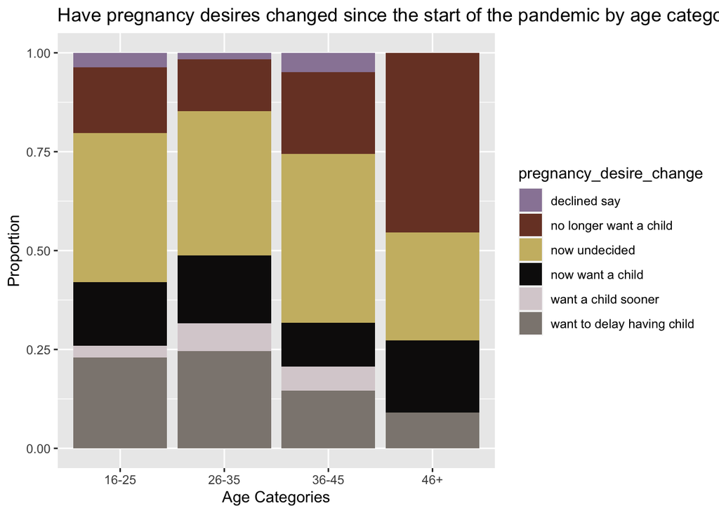

```r
# pregnancy desires by age categories
plot_preg_age <- IHME_data_clean %>%
  drop_na(pregnancy_desire_change) %>% #dropping missing values
ggplot() +
  aes(x = age_category, fill = pregnancy_desire_change) +
  geom_bar(position = "fill") +
  labs(title = "Have pregnancy desires changed since the start of the pandemic by age categories?",
       x = "Age Categories",
       y = "Proportion") +
    scale_fill_manual(values = wes_palette("IsleofDogs1"))
plot_preg_age
```

I also want to look at change of contraceptive use and see if there are any differences by country-level income which I hypothesized cound influence access

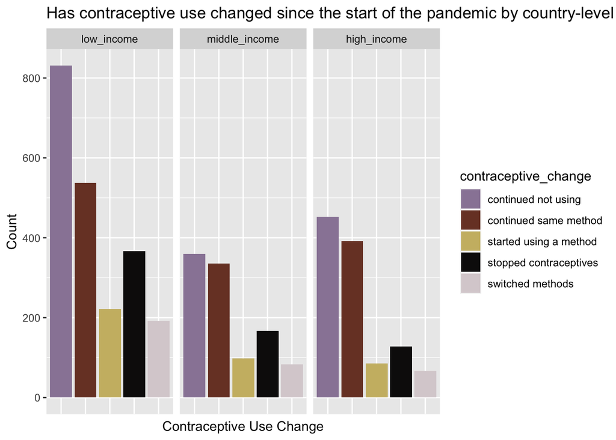

```r
#Contraceptive change, with facet wrap country income
plot_cont <- ggplot(IHME_data_clean) +
  aes(x = contraceptive_change, fill = contraceptive_change) +
  geom_bar() +
  facet_wrap(vars(country_income)) +
 labs(title = "Has contraceptive use changed since the start of the pandemic by country-level income?",
       x = "Contraceptive Use Change",
       y = "Count") +
    theme(axis.text.x=element_blank(),
          axis.ticks.x=element_blank()) +
  scale_fill_manual(values = wes_palette("IsleofDogs1"))
plot_cont
```

Finally, I want to look at perceived safety and perceptions of alcohol use changes, over all. And will use bar graphs

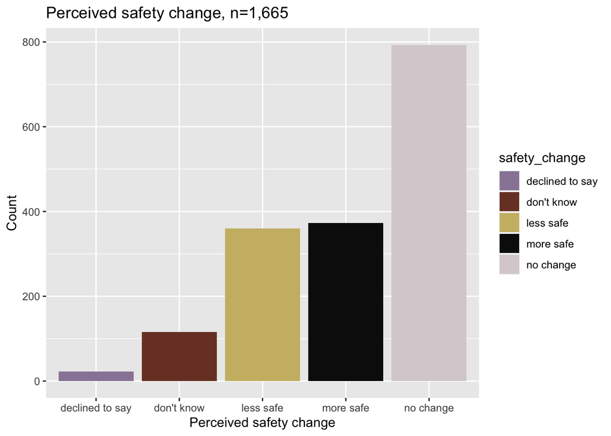

```r
#Safety change plot
plot_safety <- IHME_data_clean %>%
  drop_na(safety_change) %>% #dropping missing values
ggplot() +
  aes(x = safety_change, fill = safety_change) +
  geom_bar() +
  labs(title = "Perceived safety change, n=1,665",
       x = "Perceived safety change",
       y = "Count") +
  scale_fill_manual(values = wes_palette("IsleofDogs1"))
plot_safety
```

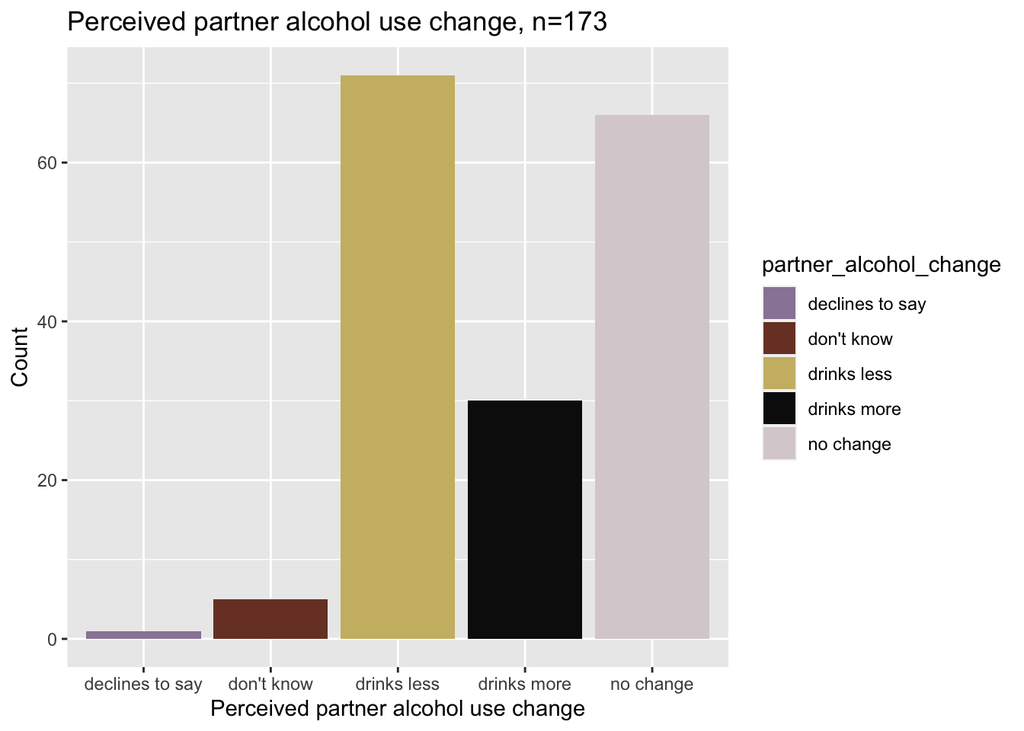

```r
plot_alcohol <- IHME_data_clean %>%
  drop_na(partner_alcohol_change) %>% #dropping missing values
ggplot() +
  aes(x = partner_alcohol_change, fill = partner_alcohol_change) +
  geom_bar() +
  labs(title = "Perceived partner alcohol use change, n=173",
       x = "Perceived partner alcohol use change",
       y = "Count") +
  scale_fill_manual(values = wes_palette("IsleofDogs1"))
plot_alcohol
```

## Final Summary (10 points)

> *Summarize your research question and findings below.*

> *Are your findings what you expected? Why or Why not?*

As expected I did find some changes in pregancy desires. I also saw some shifts in contraceptive use but they were mostly stable. I believe there are several reasons why it’s a bit of a messy picture. Desires and contraceptive use likely shift anyway and there are many confounding factors (age, income, education, etc); I did not attept to control for any of that. Also, there was a lot of missing data and this survey was not designed to be a representative sample.